# 8: Report outputs for a single country

FAO Climate Change Risks to Fed Mariculture

Author

Tormey Reimer

Published

3 November 2026

← Previous: Habitat suitability

Next: Home →

# Overview

The purpose of this document is to generate all the required report outputs (plots, data) for a single country. Change `this_iso` in the chunk below and re-render to produce outputs for a different country.

**Choose the country we’re looking at.**

```r
this_iso <- "IDN"

assigned_farms <- file.path(prepdata_path, "assigned_farms_final.qs") %>%
  qs_read() %>%
  filter(ISO3_Code == this_iso)

this_country  <- unique(assigned_farms$country)
farm_IDs  <- unique(assigned_farms$farm_ID)

production_files <- file.path(
  outs_path, "data", "farm_production_consolidated",
  paste0(this_iso, "_", unique(assigned_farms$model_name), ".qs")
)

GLW_ls <- list(
  "GLW_1.5" = 2018:2037,
  "GLW_2.0" = 2032:2051,
  "GLW_3.0" = 2055:2074,
  "GLW_4.0" = 2075:2094
)

# This fills out 1 cell of border around the EEZ HS values close to the coastline, purely to stop the ugly white spaces between the coast and the HS data. Note that this gapfilling technically extrapolates "fake" data within the country's EEZ, so country HS stats/numbers need to be calculated BEFORE gapfilling.
land       <- ne_countries(scale = "large", returnclass = "sf")
this_land  <- land %>% filter(iso_a3 == this_iso | adm0_a3 == this_iso)
coast_zone <- buffer(vect(this_land), 62500)   # band around the coast
fill_coastal_gaps <- function(r, w = 3) {
  filled <- focal(r, w, "mean", na.rm = TRUE, na.policy = "only")
  cover(r, mask(filled, coast_zone))       # only fill NAs that fall inside the coastal band
}

# Models present in this country, with a colour for each. Models not in`models_pal` (e.g. tuna) get a grey fallback.
models_here <- sort(unique(assigned_farms$model_name))
country_pal <- models_pal[models_here]
names(country_pal) <- models_here
country_pal[is.na(country_pal)] <- "grey50"

# Readable labels for model names
label_model <- function(x) str_replace_all(x, "_", " ") %>% str_to_sentence()

GLW_labels <- c("GLW_1.5" = "1.5°C", "GLW_2.0" = "2°C", "GLW_3.0" = "3°C", "GLW_4.0" = "4°C")

# prettyplot() removes the legend; add it back (with its title) for the report plots
report_theme <- function(legend = "bottom") {
  prettyplot() +
    theme(legend.position = legend, legend.title = element_text())
}

year_breaks <- seq(2025, 2095, 10)
```

# Farms

## Farm locations

**Map of assigned farms**

```r
ggplot() +
  geom_sf(data = land, fill = "grey85", colour = "grey55", linewidth = 0.2) +
  geom_sf(data = assigned_farms, aes(colour = model_name), size = 2) +
  geom_text(
    data = assigned_farms %>%
      filter(farm_ID %in% c(95561, 95562, 95563)) %>%
      mutate(X = st_coordinates(geometry)[,"X"], Y = st_coordinates(geometry)[,"Y"]),
    aes(x = X, y = Y, label = farm_ID)
    ) +
  scale_colour_manual(values = country_pal, labels = label_model, name = "Model") +
  do.call(coord_sf, bbox_lims(this_iso)) +
  labs(
    title = paste0("Assigned farms: ", this_country, " (", this_iso, ")"),
    x = NULL, y = NULL
  ) +
  report_theme()
```

[output not shown]

## Farms per model

**Summary table of farms per model**

```r
# Farm IDs that actually have a production file
# farm_IDs_done <- basename(production_files) %>%
#   str_extract("(?<=farmID_)\\d+") %>%
#   as.numeric()

assigned_farms %>%
  st_drop_geometry() %>%
  group_by(model_name) %>%
  reframe(
    n_farms = n(),
    production_t = unique(value),
    production_perfarm_t = unique(prod_perfarm)
  ) %>%
  arrange(desc(production_t)) %>%
  knitr::kable(
    digits = 1,
    col.names = c("Model", "Farms", "Reported production (t)", "Production per farm (t)")
  )
```

| Model | Farms | Reported production (t) | Production per farm (t) |
| --- | --- | --- | --- |
| milkfish | 433 | 376946.9 | 870.5 |
| whiteleg_shrimp | 520 | 175074.3 | 336.7 |
| tiger_prawn | 418 | 140611.5 | 336.4 |
| nile_tilapia | 60 | 51899.8 | 865.0 |
| mud_crab | 22 | 7087.2 | 322.1 |
| grouper | 8 | 5864.6 | 733.1 |
| golden_pompano | 2 | 460.0 | 230.0 |

**Examine production file error report for failed farms**

```r
errored <- file.path(outs_path, "production_check_high_error_files_decisions.xlsx") %>%
  read_excel() %>%
  mutate(farm_ID = as.integer(str_remove_all(file, "production_results_farmID_|_MC5000.qs"))) %>%
  filter(farm_ID %in% farm_IDs & Conclusion == "Exclude")

if (nrow(errored) > 0) {
  errored %>%
    dplyr::select(-c(country)) %>%
    left_join(assigned_farms, by = join_by(farm_ID, model_name)) %>%
    group_by(country, model_name, reason) %>%
    reframe(n_farms = n()) %>%
    knitr::kable(
      col.names = c("Country", "Model", "Error detail", "No. farms")
    )
} else {
  message("No farms excluded due to run errors.")
}
```

## Country production summary

**Report coverage FAO production data**

```r
file.path(prepdata_path, "FAO_with_models.qs") %>%
  qs_read() %>%
  filter(period %in% 2014:2023 & ISO3_Code == this_iso) %>%
  mutate(model_name = case_when(
    model_name %in% c("drum", "large_yellow_croaker", "whitemouth_croaker", "meagre") ~ "drum_croaker",
    model_name %in% c("red_seabream", "gilthead_seabream", "blackhead_seabream") ~ "seabream",
    TRUE ~ model_name)
  ) %>%
  # Average each species over the years it was reported (missing years = not reported, not zero),
  # then sum species within a model. This matches country_summary().
  group_by(ISO3_Code, country, model_name, Scientific_Name, period) %>%
  reframe(value = sum(value)) %>%
  group_by(ISO3_Code, country, model_name, Scientific_Name) %>%
  reframe(value = mean(value)) %>%
  group_by(ISO3_Code, country, model_name) %>%
  reframe(value = sum(value)) %>%
  mutate(included = case_when(model_name %in% models_here ~ T, T ~ F)) %>%
  knitr::kable(
    digits = 1,
    col.names = c("ISO", "Country", "Model", "Mean production (2014-2023)", "Included")
  )
```

| ISO | Country | Model | Mean production (2014-2023) | Included |
| --- | --- | --- | --- | --- |
| IDN | Indonesia | barramundi | 4904.0427 [t] | FALSE |
| IDN | Indonesia | cobia | 4.0000 [t] | FALSE |
| IDN | Indonesia | flathead_grey_mullet | 10261.6154 [t] | FALSE |
| IDN | Indonesia | general_crustacean | 7521.0000 [t] | FALSE |
| IDN | Indonesia | general_fish | 70364.6668 [t] | FALSE |
| IDN | Indonesia | golden_pompano | 460.0290 [t] | TRUE |
| IDN | Indonesia | grouper | 23951.9999 [t] | TRUE |
| IDN | Indonesia | milkfish | 588414.7563 [t] | TRUE |
| IDN | Indonesia | mud_crab | 15720.2306 [t] | TRUE |
| IDN | Indonesia | nile_tilapia | 95920.5398 [t] | TRUE |
| IDN | Indonesia | sandfish_sea_cucumber | 988.7388 [t] | FALSE |
| IDN | Indonesia | swimming_crab | 2995.7303 [t] | FALSE |
| IDN | Indonesia | tiger_prawn | 135944.2022 [t] | TRUE |
| IDN | Indonesia | whiteleg_shrimp | 651780.2184 [t] | TRUE |

Output of `country_summary()`: FAO-reported production (2014–2023) by model and by species within each model.

**Run country_summary()**

```r
country_summary(this_iso)
```

```
Indonesia (IDN)
Total production: 1,609,232 t
Number of models: 14

  whiteleg_shrimp: 651,780 t (40.5% of country total)
    - Penaeus vannamei: 599,953 t (92.0% of model)
    - Metapenaeus spp: 40,790 t (6.3% of model)
    - Penaeus merguiensis: 10,620 t (1.6% of model)
    - Metapenaeopsis novaeguineae: 417 t (0.1% of model)

  milkfish: 588,415 t (36.6% of country total)
    - Chanos chanos: 588,415 t (100.0% of model)

  tiger_prawn: 135,944 t (8.4% of country total)
    - Penaeus monodon: 135,944 t (100.0% of model)

  nile_tilapia: 95,921 t (6.0% of country total)
    - Oreochromis niloticus: 69,099 t (72.0% of model)
    - Oreochromis mossambicus: 26,822 t (28.0% of model)

  general_fish: 70,365 t (4.4% of country total)
    - Osteichthyes: 60,014 t (85.3% of model)
    - Actinopterygii: 10,351 t (14.7% of model)

  grouper: 23,952 t (1.5% of country total)
    - Epinephelus spp: 15,585 t (65.1% of model)
    - Epinephelus fuscoguttatus: 5,736 t (23.9% of model)
    - Epinephelus longispinis: 971 t (4.1% of model)
    - Chromileptes altivelis: 520 t (2.2% of model)
    - Gracila albomarginata: 436 t (1.8% of model)
    - Serranidae: 390 t (1.6% of model)
    - Epinephelus bleekeri: 181 t (0.8% of model)
    - Plectropomus laevis: 134 t (0.6% of model)
    - Plectropomus oligacanthus: 0 t (0.0% of model)

  mud_crab: 15,720 t (1.0% of country total)
    - Scylla serrata: 9,837 t (62.6% of model)
    - Scylla olivacea: 5,883 t (37.4% of model)

  flathead_grey_mullet: 10,262 t (0.6% of country total)
    - Mugil cephalus: 5,366 t (52.3% of model)
    - Mugilidae: 4,896 t (47.7% of model)

  general_crustacean: 7,521 t (0.5% of country total)
    - Carpilius maculatus: 7,420 t (98.7% of model)
    - Acetes indicus: 101 t (1.3% of model)

  barramundi: 4,904 t (0.3% of country total)
    - Lates calcarifer: 4,904 t (100.0% of model)

  swimming_crab: 2,996 t (0.2% of country total)
    - Portunus spp: 2,996 t (100.0% of model)

  sandfish_sea_cucumber: 989 t (0.1% of country total)
    - Holothuroidea: 989 t (100.0% of model)

  golden_pompano: 460 t (0.0% of country total)
    - Trachinotus blochii: 460 t (100.0% of model)

  cobia: 4 t (0.0% of country total)
    - Rachycentron canadum: 4 t (100.0% of model)
```

# Farm production

Annual biomass harvested and feed required, relative to the 2025 baseline, from the farm production model runs. Lines show the mean across farms within each model and ribbons show ± 1 standard deviation.

**Load farm production data**

```r
farm_data <- get_country_data2(production_files) %>%
  left_join(
    assigned_farms %>% st_drop_geometry() %>% dplyr::select(farm_ID),
    by = join_by(farm_ID)
  ) %>%
  mutate(
    farm_ID = as.factor(farm_ID)
  )

# Some plotting globals
model_order <- farm_data %>%
  group_by(model_name) %>%
  reframe(biomass_2025 = mean(biomass_2025)) %>%
  arrange(-biomass_2025) %>%
  pull(model_name)

warming_cols <- c("1.5°C" = "#E9A23B", "2°C"   = "#DB5F32", "3°C"   = "#B3243B", "4°C"   = "#5C0F2E")
offsets <- c("1.5°C" = -0.24, "2°C" = -0.08, "3°C" = 0.08, "4°C" = 0.24)

# Shared plotting function: mean across farms (line) ± 1 SD (ribbon) per model
plot_farm_change <- function(df, y, ylab, title) {
  df %>%
    group_by(model_name, year) %>%
    reframe(
      mean = 100*mean({{ y }}, na.rm = T),
      sd = 100*sd({{ y }}, na.rm = T)
    ) %>%
    ggplot(aes(x = year, colour = model_name, fill = model_name)) +
    geom_hline(yintercept = 0, colour = "grey45", linewidth = 0.5, linetype = "dashed") +
    geom_ribbon(aes(ymin = mean - sd, ymax = mean + sd), alpha = 0.2, colour = NA) +
    geom_line(aes(y = mean), linewidth = 0.8) +
    scale_colour_manual(values = country_pal, labels = label_model, name = "Model") +
    scale_fill_manual(values = country_pal, labels = label_model, name = "Model") +
    scale_x_continuous(breaks = year_breaks) +
    labs(title = title, x = "Year", y = ylab) +
    report_theme()
}
```

Median (and interquartile range) relative change across farms within each model, for each global warming level.

**Summarise production change per model and GLW**

```r
# yrs <- GLW_ls[[1]]
# nm <- names(GLW_ls)[1]
farm_data_GLW <- map2_dfr(
  GLW_ls,
  names(GLW_ls),
  function(yrs, nm) {
    farm_data %>%
      filter(year %in% yrs) %>%
      group_by(farm_ID, model_name) %>%
      reframe(
        biomass_change_pct        = 100* mean(biomass_change_pct, na.rm = T),
        feed_prov_change_pct      = 100* mean(feed_prov_change_pct, na.rm = T),
        feed_prov_biom_change_pct = 100* mean(feed_prov_biom_change_pct, na.rm = T)
      ) %>%
      mutate(GLW = nm)
  }
) %>%
  mutate(GLW = factor(GLW, levels = names(GLW_labels), labels = GLW_labels))

farm_data_GLW %>%
  group_by(model_name, GLW) %>%
  reframe(
    n_farms = n(),
    biomass_median = median(biomass_change_pct, na.rm = T),
    biomass_q25 = quantile(biomass_change_pct, 0.25, na.rm = T),
    biomass_q75 = quantile(biomass_change_pct, 0.75, na.rm = T),
    feed_median = median(feed_prov_biom_change_pct, na.rm = T),
    feed_q25 = quantile(feed_prov_biom_change_pct, 0.25, na.rm = T),
    feed_q75 = quantile(feed_prov_biom_change_pct, 0.75, na.rm = T)
  ) %>%
  knitr::kable(
    digits = 1,
    col.names = c("Model", "GLW", "Farms", "Biomass median (%)", "Q25", "Q75", "Feed/biomass median (%)", "Q25", "Q75")
  )
```

| Model | GLW | Farms | Biomass median (%) | Q25 | Q75 | Feed/biomass median (%) | Q25 | Q75 |
| --- | --- | --- | --- | --- | --- | --- | --- | --- |
| golden_pompano | 1.5°C | 2 | -2.3 | -2.3 | -2.3 | -0.6 | -0.6 | -0.6 |
| golden_pompano | 2°C | 2 | -9.6 | -9.7 | -9.6 | -0.3 | -0.3 | -0.3 |
| golden_pompano | 3°C | 2 | -35.5 | -35.5 | -35.4 | 1.7 | 1.7 | 1.7 |
| golden_pompano | 4°C | 2 | -62.3 | -62.3 | -62.3 | 5.4 | 5.4 | 5.4 |
| grouper | 1.5°C | 8 | -3.2 | -3.3 | -2.9 | -0.5 | -0.5 | -0.4 |
| grouper | 2°C | 8 | -4.3 | -4.3 | -4.0 | -0.6 | -0.6 | -0.6 |
| grouper | 3°C | 8 | -19.3 | -19.4 | -19.0 | -3.1 | -3.1 | -3.0 |
| grouper | 4°C | 8 | -37.4 | -37.5 | -37.2 | -6.6 | -6.6 | -6.5 |
| milkfish | 1.5°C | 433 | -1.1 | -1.5 | -0.6 | -0.1 | -0.1 | 0.0 |
| milkfish | 2°C | 433 | -1.6 | -2.0 | -1.1 | -0.1 | -0.2 | 0.0 |
| milkfish | 3°C | 433 | -5.5 | -6.5 | -4.0 | -0.6 | -0.8 | -0.3 |
| milkfish | 4°C | 433 | -10.5 | -12.3 | -8.2 | -1.4 | -1.8 | -1.0 |
| mud_crab | 1.5°C | 22 | -4.2 | -5.1 | -0.7 | 1.7 | -0.7 | 2.6 |
| mud_crab | 2°C | 22 | -6.8 | -8.0 | -4.2 | 2.4 | 0.8 | 3.9 |
| mud_crab | 3°C | 22 | -23.6 | -25.1 | -20.2 | 10.0 | 8.1 | 11.7 |
| mud_crab | 4°C | 22 | -44.1 | -44.8 | -36.5 | 20.0 | 16.4 | 23.0 |
| nile_tilapia | 1.5°C | 60 | -0.1 | -0.9 | 0.2 | 0.3 | -0.2 | 1.3 |
| nile_tilapia | 2°C | 60 | 0.1 | -0.5 | 0.6 | 2.2 | 1.3 | 3.4 |
| nile_tilapia | 3°C | 60 | -2.3 | -4.9 | -1.3 | 8.9 | 6.8 | 10.8 |
| nile_tilapia | 4°C | 60 | -10.9 | -16.4 | -7.5 | 15.1 | 13.6 | 20.1 |
| tiger_prawn | 1.5°C | 418 | -4.0 | -5.0 | -2.4 | 0.0 | -0.2 | 0.2 |
| tiger_prawn | 2°C | 418 | -5.8 | -7.4 | -4.3 | 0.1 | -0.3 | 0.5 |
| tiger_prawn | 3°C | 418 | -20.7 | -24.8 | -15.3 | -1.7 | -3.0 | 0.5 |
| tiger_prawn | 4°C | 418 | -39.2 | -46.6 | -32.6 | -5.9 | -7.9 | -4.0 |
| whiteleg_shrimp | 1.5°C | 520 | -2.7 | -4.0 | -1.2 | 0.2 | 0.0 | 0.3 |
| whiteleg_shrimp | 2°C | 520 | -3.6 | -5.3 | -2.3 | 0.2 | 0.0 | 0.4 |
| whiteleg_shrimp | 3°C | 520 | -12.1 | -15.9 | -9.6 | -0.1 | -0.5 | 0.6 |
| whiteleg_shrimp | 4°C | 520 | -23.1 | -28.0 | -18.1 | -0.8 | -1.5 | 0.3 |

## Change in biomass

**Plot change in harvested biomass**

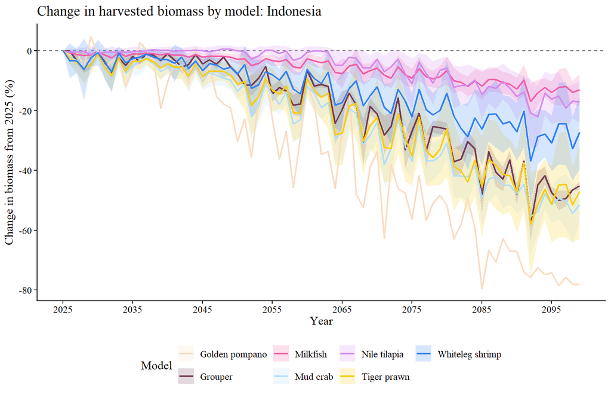

```r
plot_farm_change(
  farm_data, biomass_change_pct,
  ylab = "Change in biomass from 2025 (%)",
  title = paste0("Change in harvested biomass by model: ", this_country)
)
```

**Plot production change per model and GLW**

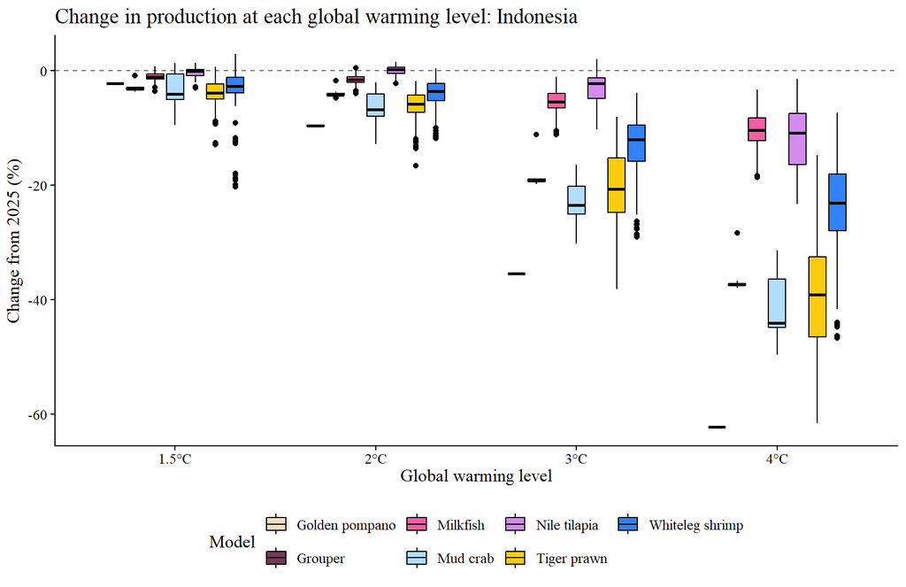

```r
farm_data_GLW %>%
  ggplot(aes(x = GLW, y = biomass_change_pct, fill = model_name)) +
  geom_hline(yintercept = 0, colour = "grey45", linewidth = 0.5, linetype = "dashed") +
  geom_boxplot(position = position_dodge(width = 0.7), width = 0.6, colour = "black") +
  scale_fill_manual(values = country_pal, labels = label_model, name = "Model") +
  labs(
    title = paste0("Change in production at each global warming level: ", this_country),
    x = "Global warming level", y = "Change from 2025 (%)"
  ) +
  report_theme()
```

**Plot production change per model and GLW - dot and line approach**

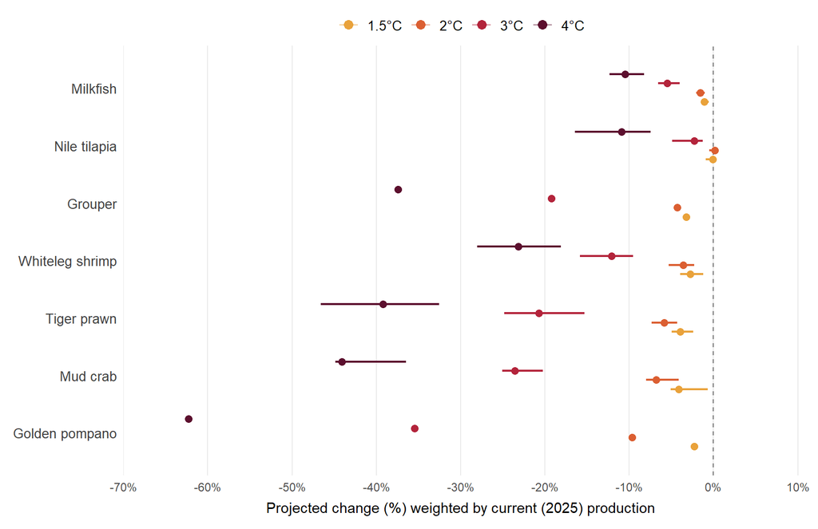

```r
plt_data <- farm_data_GLW %>%
  mutate(biomass_change_pct = biomass_change_pct/100) %>%
  group_by(model_name, GLW) %>%
  reframe(
    median = median(biomass_change_pct),
    q25 = quantile(biomass_change_pct, 0.25),
    q75 = quantile(biomass_change_pct, 0.75)
  ) %>%
  mutate(
    model_name = factor(model_name, levels = rev(model_order)),
    y = as.numeric(model_name) + offsets[as.character(GLW)]
  )

plt_limits <- pct_limits(c(plt_data$q25, plt_data$q75))
plt_breaks <- pct_breaks(c(plt_data$q25, plt_data$q75))

plt_data %>%
  ggplot(aes(x = y, y = median, colour = GLW)) +
  geom_hline(yintercept = 0, colour = "grey45", linewidth = 0.5, linetype = "dashed") +
  geom_segment(aes(y = q25, yend = q75), linewidth = 0.8) +
  geom_point(aes(y = median), size = 2.3) +
  scale_colour_manual(values = warming_cols, name = NULL) +
  scale_y_continuous(
    breaks = plt_breaks,
    labels = scales::label_percent(),
    limits = plt_limits,
    expand = expansion(0)
  ) +
  scale_x_continuous(
    breaks = seq_along(rev(model_order)),
    labels = label_model(rev(model_order)),
    expand = expansion(add = 0.5)
  ) +
  coord_flip() +
  labs(
    y = "Projected change (%) weighted by current (2025) production",
    x = NULL
  ) +
  guides(colour = guide_legend(override.aes = list(linewidth = 0, size = 3))) +
  theme_minimal(base_size = 11) +
  theme(
    plot.title            = element_text(face = "bold", size = 14),
    plot.subtitle         = element_text(size = 10, margin = margin(b = 6)),
    plot.title.position   = "plot",
    plot.caption.position = "plot",
    plot.caption          = element_text(hjust = 0, colour = "grey45", size = 9),
    legend.position       = "top",
    legend.justification  = "center",
    legend.text           = element_text(size = 10),
    legend.margin         = margin(b = -4),
    panel.grid.major.y    = element_blank(),
    panel.grid.minor      = element_blank(),
    panel.grid.major.x    = element_line(colour = "grey92", linewidth = 0.4),
    axis.text.y           = element_text(colour = "grey25", size = 10),
    axis.title.x          = element_text(margin = margin(t = 6)),
    plot.margin           = margin(10, 15, 10, 10)
  )
```

## Change in feed per unit biomass

Feed required per unit of harvested biomass. An increase means more feed is needed to produce the same amount of fish.

**Plot change in feed per unit biomass**

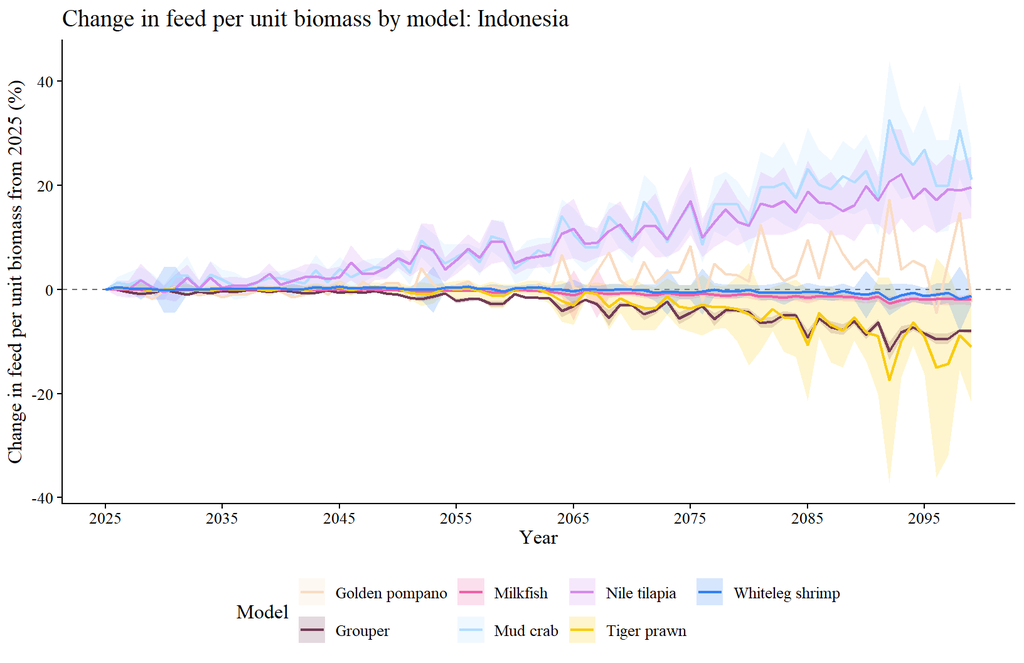

```r
plot_farm_change(
  farm_data, feed_prov_biom_change_pct,
  ylab = "Change in feed per unit biomass from 2025 (%)",
  title = paste0("Change in feed per unit biomass by model: ", this_country)
)
```

**Plot feed change per biomass per model and GLW**

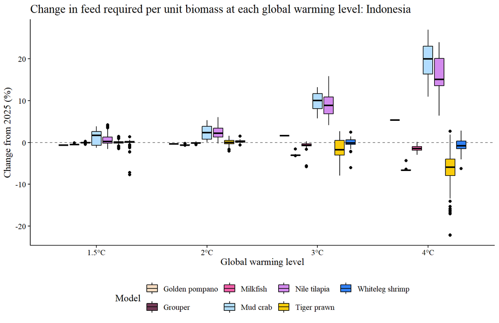

```r
farm_data_GLW %>%
  ggplot(aes(x = GLW, y = feed_prov_biom_change_pct, fill = model_name)) +
  geom_hline(yintercept = 0, colour = "grey45", linewidth = 0.5, linetype = "dashed") +
  geom_boxplot(position = position_dodge(width = 0.7), width = 0.6, colour = "black") +
  scale_fill_manual(values = country_pal, labels = label_model, name = "Model") +
  labs(
    title = paste0("Change in feed required per unit biomass at each global warming level: ", this_country),
    x = "Global warming level", y = "Change from 2025 (%)"
  ) +
  report_theme()
```

**Plot feed per biomass change per model and GLW - dot and line approach**

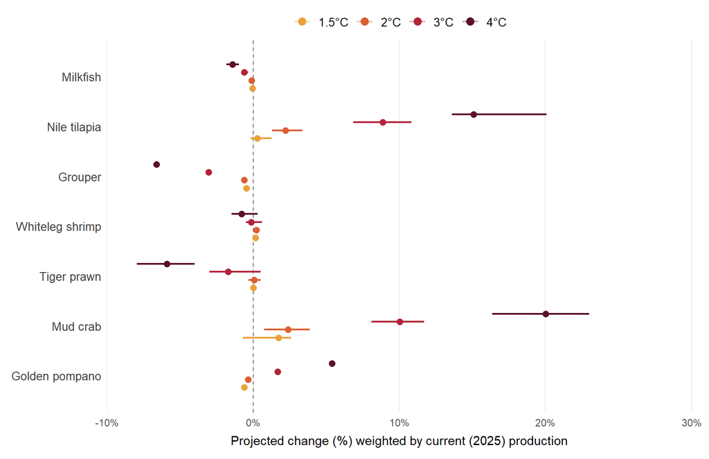

```r
plt_data <- farm_data_GLW %>%
  mutate(feed_prov_biom_change_pct = feed_prov_biom_change_pct/100) %>%
  group_by(model_name, GLW) %>%
  reframe(
    median = median(feed_prov_biom_change_pct),
    q25 = quantile(feed_prov_biom_change_pct, 0.25),
    q75 = quantile(feed_prov_biom_change_pct, 0.75)
  ) %>%
  mutate(
    model_name = factor(model_name, levels = rev(model_order)),
    y = as.numeric(model_name) + offsets[as.character(GLW)]
  )

plt_limits <- pct_limits(c(plt_data$q25, plt_data$q75))
plt_breaks <- pct_breaks(c(plt_data$q25, plt_data$q75))

plt_data %>%
  ggplot(aes(x = y, y = median, colour = GLW)) +
  geom_hline(yintercept = 0, colour = "grey45", linewidth = 0.5, linetype = "dashed") +
  geom_segment(aes(y = q25, yend = q75), linewidth = 0.8) +
  geom_point(aes(y = median), size = 2.3) +
  scale_colour_manual(values = warming_cols, name = NULL) +
  scale_y_continuous(
    breaks = plt_breaks,
    labels = scales::label_percent(),
    limits = plt_limits,
    expand = expansion(0)
  ) +
  scale_x_continuous(
    breaks = seq_along(rev(model_order)),
    labels = label_model(rev(model_order)),
    expand = expansion(add = 0.5)
  ) +
  coord_flip() +
  labs(
    y = "Projected change (%) weighted by current (2025) production",
    x = NULL
  ) +
  guides(colour = guide_legend(override.aes = list(linewidth = 0, size = 3))) +
  theme_minimal(base_size = 11) +
  theme(
    plot.title            = element_text(face = "bold", size = 14),
    plot.subtitle         = element_text(size = 10, margin = margin(b = 6)),
    plot.title.position   = "plot",
    plot.caption.position = "plot",
    plot.caption          = element_text(hjust = 0, colour = "grey45", size = 9),
    legend.position       = "top",
    legend.justification  = "center",
    legend.text           = element_text(size = 10),
    legend.margin         = margin(b = -4),
    panel.grid.major.y    = element_blank(),
    panel.grid.minor      = element_blank(),
    panel.grid.major.x    = element_line(colour = "grey92", linewidth = 0.4),
    axis.text.y           = element_text(colour = "grey25", size = 10),
    axis.title.x          = element_text(margin = margin(t = 6)),
    plot.margin           = margin(10, 15, 10, 10)
  )
```

# Habitat suitability

**Load habitat suitability rasters**

```r
HS_path  <- file.path(outs_path, "data", "habitat_suitability_decadal", this_iso)

# Species farmed here that have an HS raster
HS_models <- intersect(models_here, list.dirs(HS_path, full.names = F, recursive = F))
lyr_names <- c("ref_2015_2024", names(GLW_ls))

# One SpatRaster per species: layers = ref + each GLW, scaled to 0-1
HS_rasts <- map(
  set_names(HS_models),
  function(m) {
    fnms <- file.path(HS_path, m, paste0("MR_", lyr_names, ".tif"))
    r <- rast(fnms) / 365
    names(r) <- lyr_names
    r
  }
)

HS_rasts_gf <- map(HS_rasts, fill_coastal_gaps)
```

Models in this country without a habitat suitability raster: none.

## Per species

**Plot habitat suitability for each species at each GLW**

```r
plot_HS <- function(r, m) {
  ggplot() +
    geom_spatraster(data = r[[names(GLW_ls)]]) +
    geom_sf(data = land, fill = "grey85", colour = "grey55", linewidth = 0.2) +
    geom_sf(data = filter(assigned_farms, model_name == m), shape = 4, size = 1) +
    facet_wrap(~lyr, nrow = 2, labeller = as_labeller(GLW_labels)) +
    scale_fill_viridis_c(
      option = "viridis",
      # limits = c(0, 1),
      na.value = "transparent", name = "Habitat\nsuitability"
    ) +
    do.call(coord_sf, bbox_lims(this_iso)) +
    labs(title = label_model(m), x = NULL, y = NULL) +
    report_theme(legend = "right") +
    theme(
      axis.text = element_text(size = 7),
      legend.key.height   = unit(4.5, "lines"),
      legend.key.width    = unit(1.2, "lines"),
      legend.frame        = element_rect(colour = "black"),
      legend.ticks        = element_line(colour = "black"),
      legend.ticks.length = unit(0.3, "lines")
    )
}

for (m in HS_models) {
  cat("\n\n### ", label_model(m), "\n\n")
  print(plot_HS(HS_rasts_gf[[m]], m))
}
```

### Golden pompano

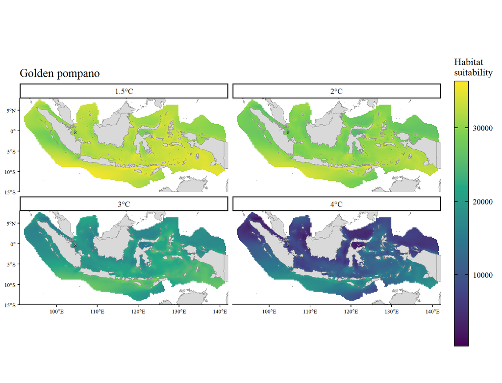

### Grouper

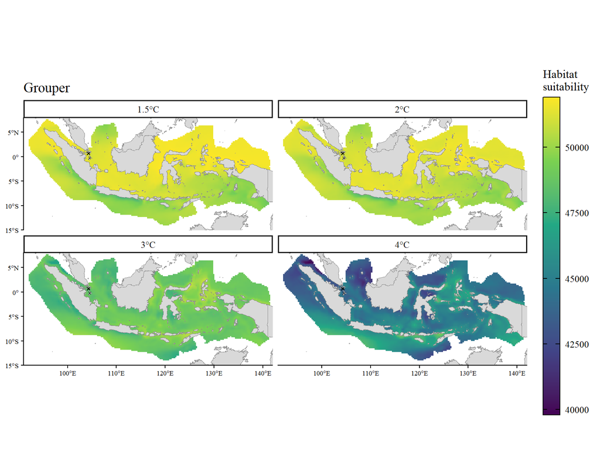

### Milkfish

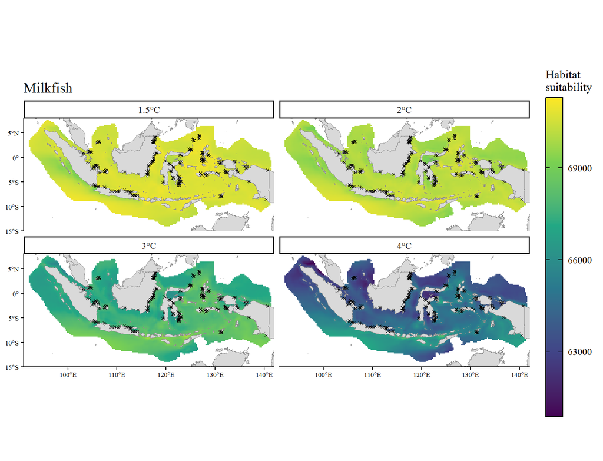

### Mud crab

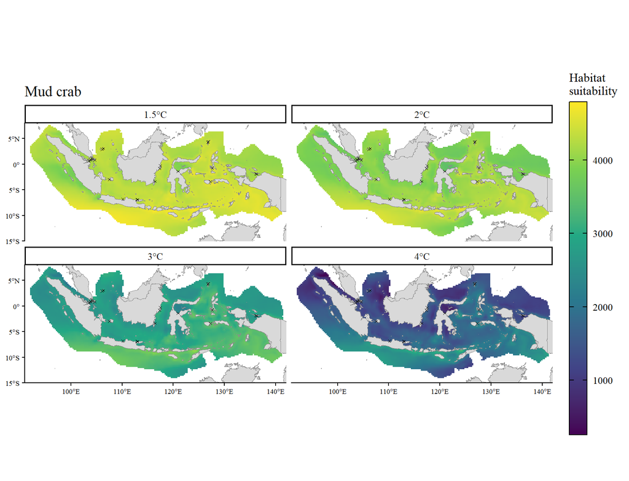

### Nile tilapia

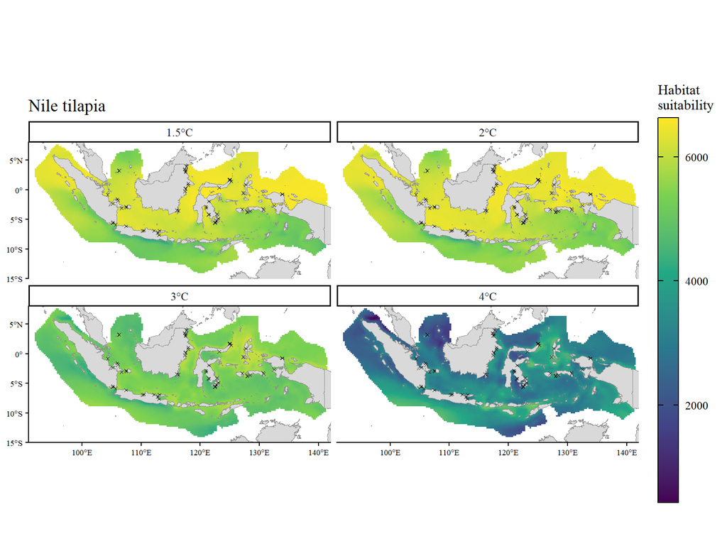

### Tiger prawn

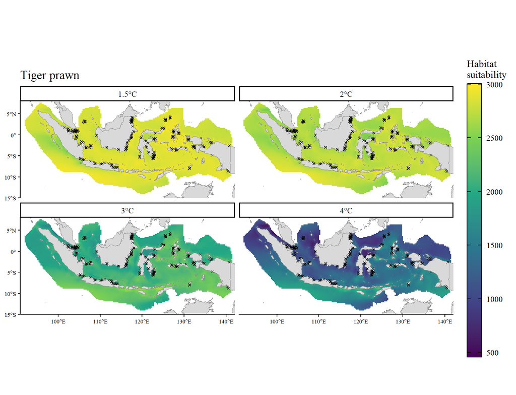

### Whiteleg shrimp

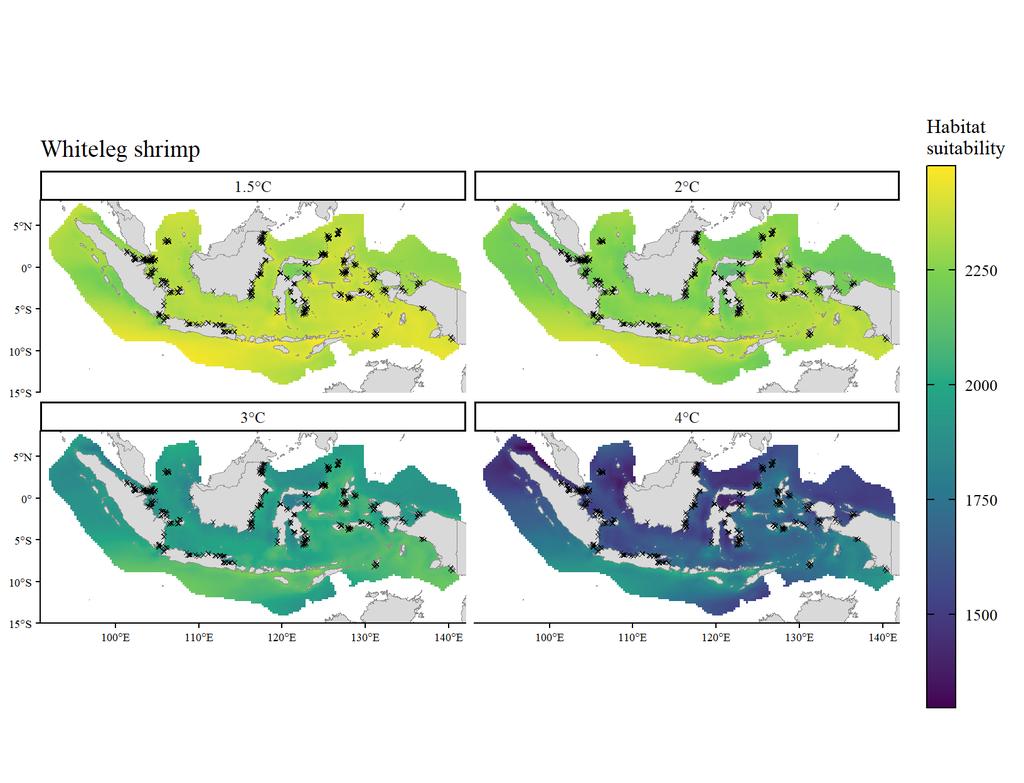

## Change per species

Relative change in habitat suitability at each GLW compared to the 2015–2024 reference period.

**Plot change in habitat suitability for each species at each GLW**

```r
HS_change <- map(HS_rasts, \(r) (r[[names(GLW_ls)]] - r[["ref_2015_2024"]]) / r[["ref_2015_2024"]])
HS_change_gf <- map(HS_change, fill_coastal_gaps)

plot_HS_change <- function(r, m) {
  lim <- max(abs(minmax(r)), na.rm = T)
  ggplot() +
    geom_spatraster(data = r) +
    geom_sf(data = land, fill = "grey85", colour = "grey55", linewidth = 0.2) +
    geom_sf(data = filter(assigned_farms, model_name == m), shape = 4, size = 1) +
    facet_wrap(~lyr, nrow = 2, labeller = as_labeller(GLW_labels)) +
    scale_fill_gradientn(
      limits = c(-lim, lim), colours = rev(cmocean("balance")(256)),
      labels = scales::label_percent(), na.value = "transparent",
      name = "Change in\nhabitat\nsuitability"
    ) +
    do.call(coord_sf, bbox_lims(this_iso)) +
    labs(title = label_model(m), x = NULL, y = NULL) +
    report_theme(legend = "right") +
    theme(
      axis.text = element_text(size = 7),
      legend.key.height   = unit(4.5, "lines"),
      legend.key.width    = unit(1.2, "lines"),
      legend.frame        = element_rect(colour = "black"),
      legend.ticks        = element_line(colour = "black"),
      legend.ticks.length = unit(0.3, "lines")
    )
}

for (m in HS_models) {
  cat("\n\n### ", label_model(m), "\n\n")
  print(plot_HS_change(HS_change_gf[[m]], m))
}
```

### Golden pompano

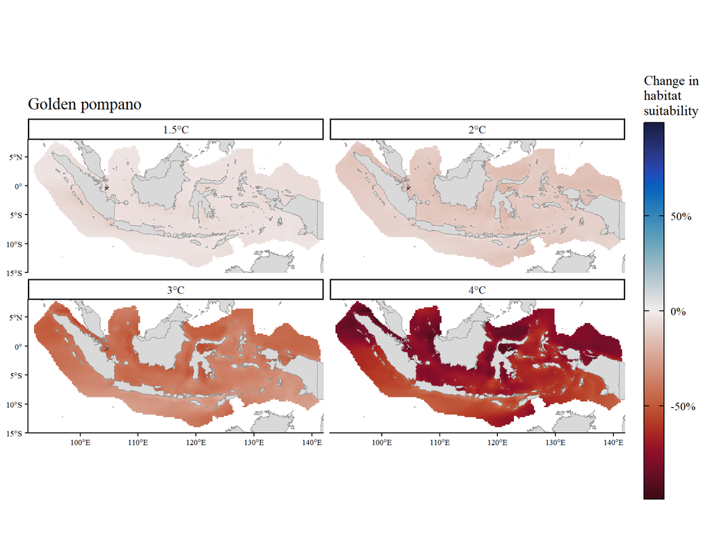

### Grouper

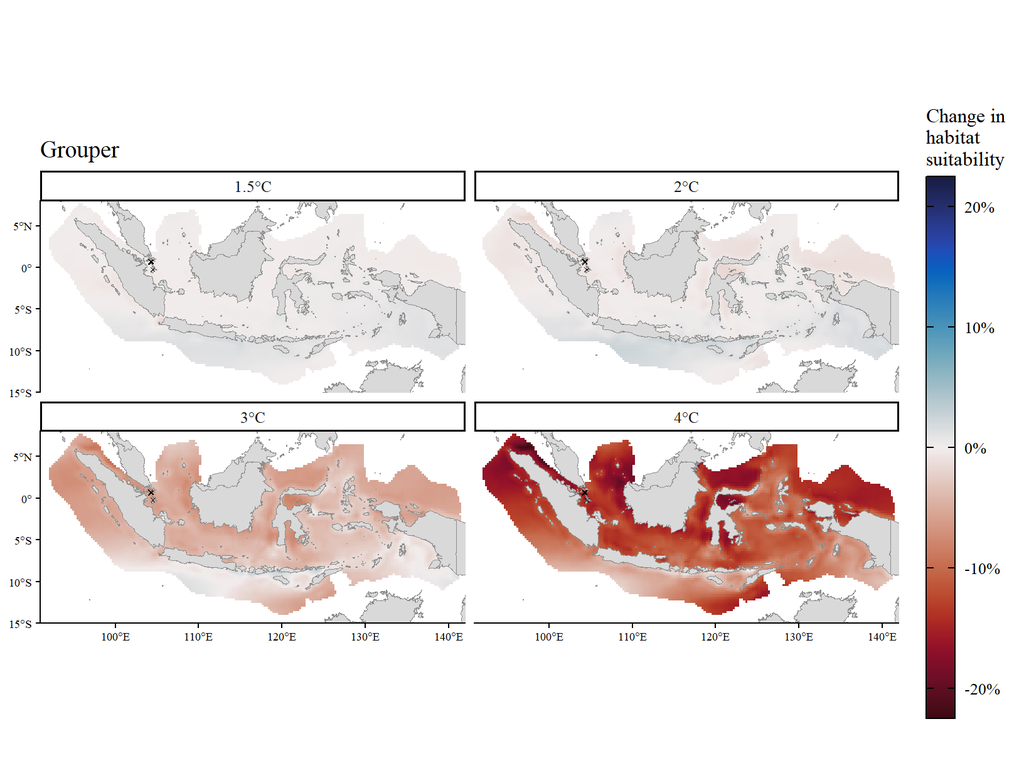

### Milkfish

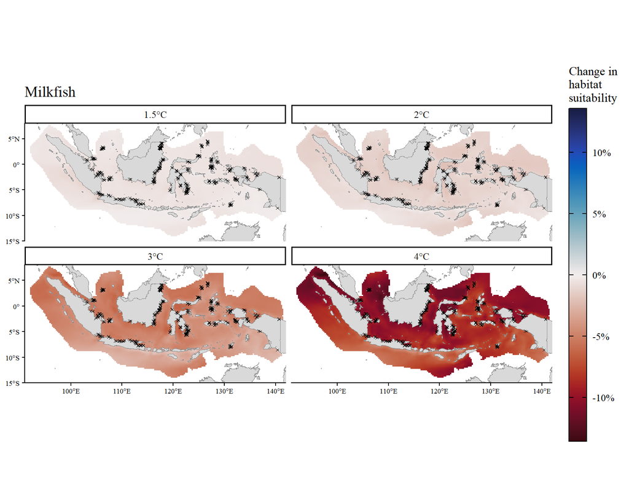

### Mud crab

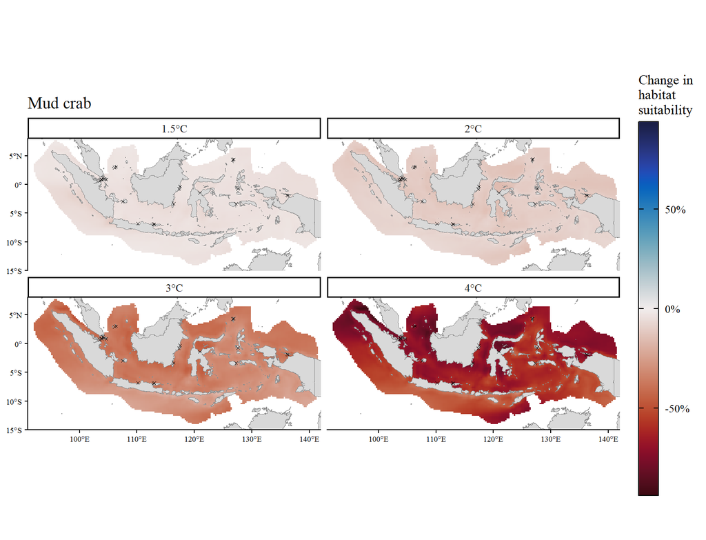

### Nile tilapia

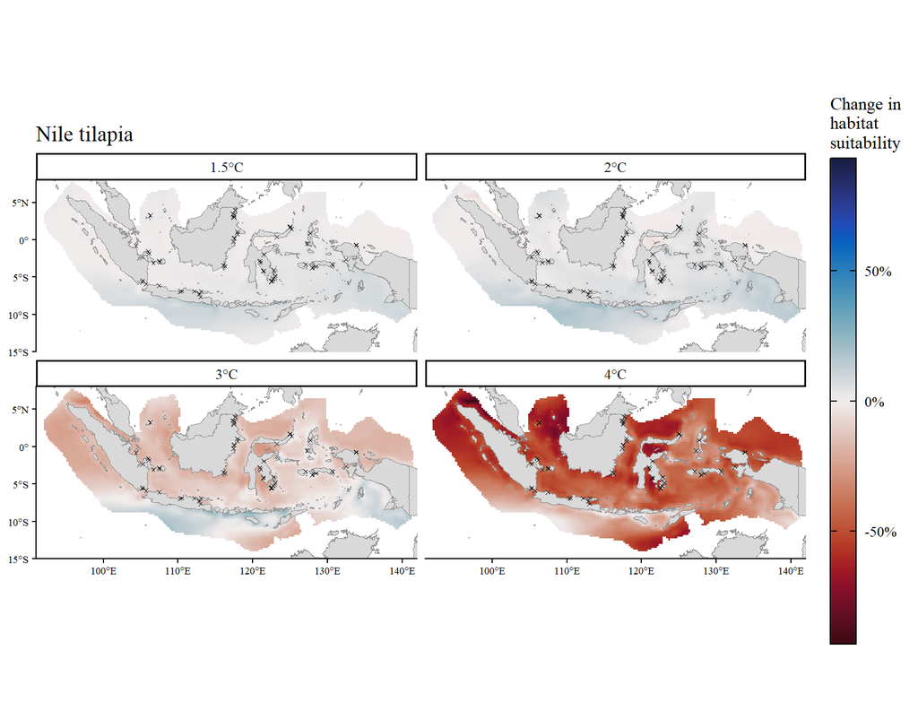

### Tiger prawn

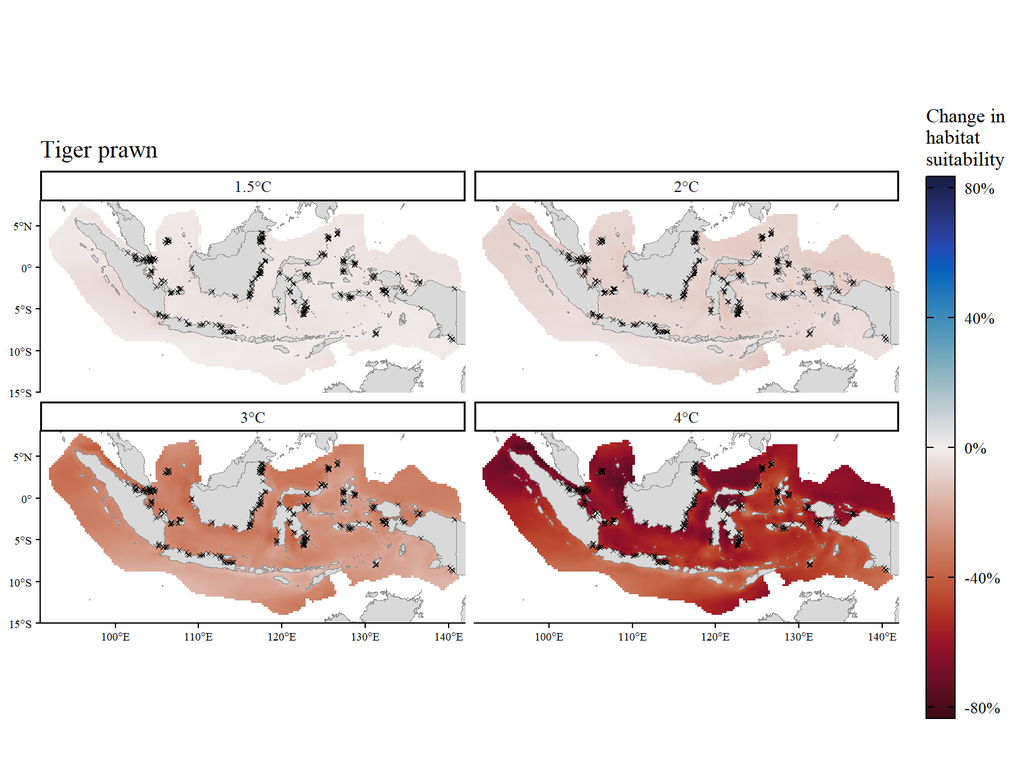

### Whiteleg shrimp

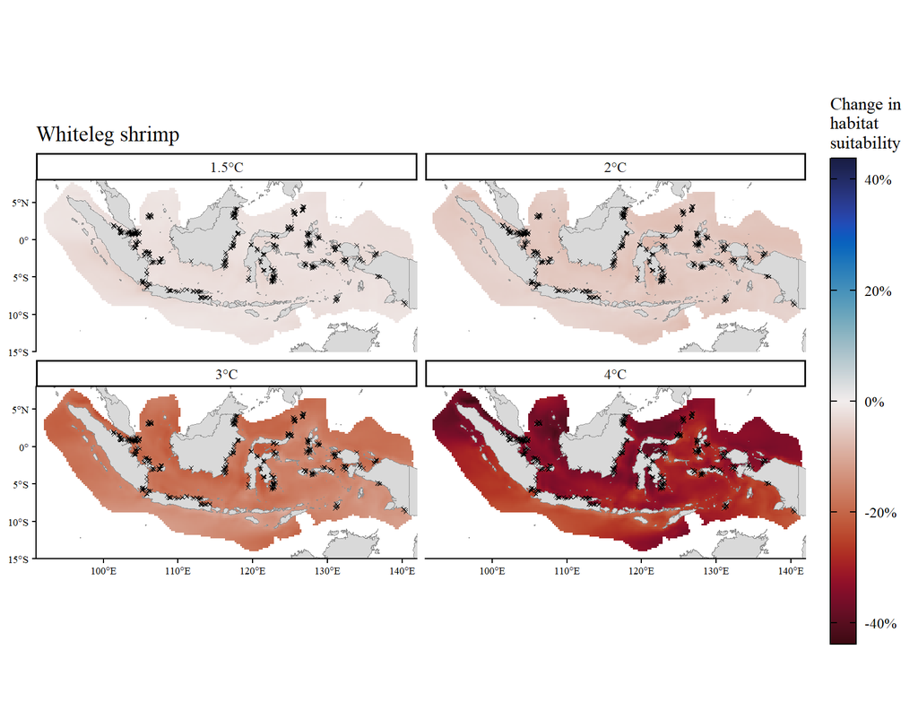

## Production-weighted habitat suitability

The species rasters combined into a single stack (one layer per GLW) by taking the mean across species, weighted by each species’ current production in the country.

**Combine species HS rasters into a production-weighted stack**

```r
HS_weights <- assigned_farms %>%
  st_drop_geometry() %>%
  distinct(model_name, value) %>%
  filter(model_name %in% HS_models)
HS_weights <- set_names(HS_weights$value, HS_weights$model_name)[HS_models]

weighted_HS <- function(rasts, weights) {
  w <- weights / sum(weights)
  Reduce(`+`, map2(rasts, w, \(r, wi) r * wi))
}

HS_weighted <- weighted_HS(HS_rasts, HS_weights)
HS_change_weighted <- weighted_HS(HS_change, HS_weights)

HS_weighted
```

```
class       : SpatRaster
size        : 87, 198, 5  (nrow, ncol, nlyr)
resolution  : 0.25, 0.25  (x, y)
extent      : 92, 141.5, -14, 7.75  (xmin, xmax, ymin, ymax)
coord. ref. : lon/lat WGS 84 (EPSG:4326)
source(s)   : memory
names       : ref_2015_2024,  GLW_1.5,  GLW_2.0,  GLW_3.0,  GLW_4.0
min values  :      36476.03, 36022.35, 36079.79, 33807.27, 31036.48
max values  :      37529.63, 37447.40, 37270.30, 36691.64, 35677.01
```

Weights used:

**Table of production weights**

```r
tibble(model = label_model(names(HS_weights)), production_t = HS_weights, weight = HS_weights / sum(HS_weights)) %>%
  knitr::kable(digits = c(0, 0, 3), col.names = c("Model", "Production (t)", "Weight"))
```

| Model | Production (t) | Weight |
| --- | --- | --- |
| Golden pompano | 460 | 0.001 |
| Grouper | 5865 | 0.008 |
| Milkfish | 376947 | 0.497 |
| Mud crab | 7087 | 0.009 |
| Nile tilapia | 51900 | 0.068 |
| Tiger prawn | 140611 | 0.186 |
| Whiteleg shrimp | 175074 | 0.231 |

**Plot production-weighted habitat suitability**

[figure not shown]

```r
HS_weighted_gf <- fill_coastal_gaps(HS_weighted)

ggplot() +
  geom_spatraster(data = HS_weighted_gf) +
  geom_sf(data = land, fill = "grey85", colour = "grey55", linewidth = 0.2) +
  geom_sf(data = filter(assigned_farms, model_name %in% HS_models), shape = 4, size = 1) +
  facet_wrap(~lyr, nrow = 2, labeller = as_labeller(GLW_labels)) +
  scale_fill_viridis_c(
    option = "viridis", limits = c(0, 1),
    na.value = "transparent", name = "Habitat\nsuitability"
  ) +
  do.call(coord_sf, bbox_lims(this_iso)) +
  labs(title = paste0("Production-weighted habitat suitability: ", this_country), x = NULL, y = NULL) +
  report_theme(legend = "right") +
  theme(
    axis.text = element_text(size = 7),
    legend.key.height   = unit(4.5, "lines"),
    legend.key.width    = unit(1.2, "lines"),
    legend.frame        = element_rect(colour = "black"),
    legend.ticks        = element_line(colour = "black"),
    legend.ticks.length = unit(0.3, "lines")
  )
```

**Plot production-weighted change in habitat suitability**

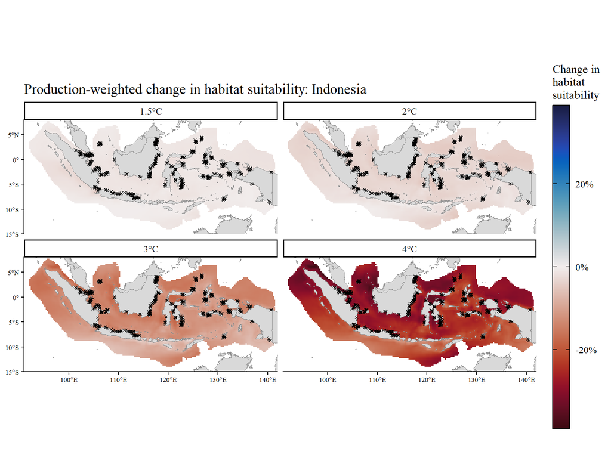

```r
HS_change_weighted_gf <- fill_coastal_gaps(HS_change_weighted)
lim <- max(abs(minmax(HS_change_weighted)), na.rm = T)

ggplot() +
  geom_spatraster(data = HS_change_weighted_gf) +
  geom_sf(data = land, fill = "grey85", colour = "grey55", linewidth = 0.2) +
  geom_sf(data = filter(assigned_farms, model_name %in% HS_models), shape = 4, size = 1) +
  facet_wrap(~lyr, nrow = 2, labeller = as_labeller(GLW_labels)) +
  # Reversed so blue = increase, red = decrease
  scale_fill_gradientn(
    limits = c(-lim, lim), colours = rev(cmocean("balance")(256)),
    labels = scales::label_percent(), na.value = "transparent",
    name = "Change in\nhabitat\nsuitability"
  ) +
  do.call(coord_sf, bbox_lims(this_iso)) +
  labs(title = paste0("Production-weighted change in habitat suitability: ", this_country), x = NULL, y = NULL) +
  report_theme(legend = "right") +
  theme(
    axis.text = element_text(size = 7),
    legend.key.height   = unit(4.5, "lines"),
    legend.key.width    = unit(1.2, "lines"),
    legend.frame        = element_rect(colour = "black"),
    legend.ticks        = element_line(colour = "black"),
    legend.ticks.length = unit(0.3, "lines")
  )
```

**Plot production-weighted change in habitat suitability (without farm markers)**

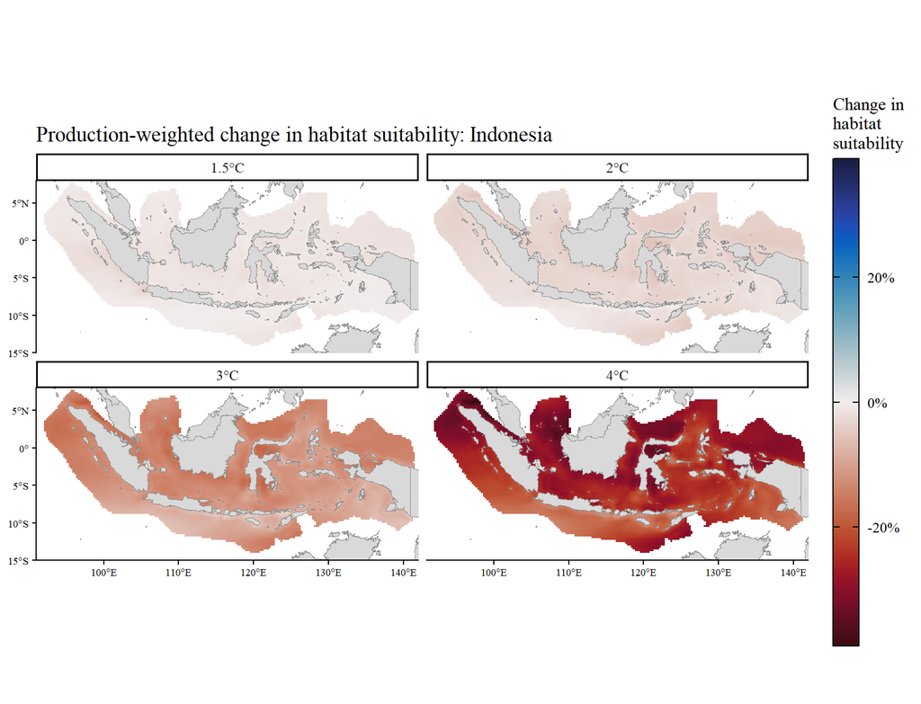

```r
HS_change_weighted_gf <- fill_coastal_gaps(HS_change_weighted)
lim <- max(abs(minmax(HS_change_weighted)), na.rm = T)

ggplot() +
  geom_spatraster(data = HS_change_weighted_gf) +
  geom_sf(data = land, fill = "grey85", colour = "grey55", linewidth = 0.2) +
  # geom_sf(data = filter(assigned_farms, model_name %in% HS_models), shape = 4, size = 1) +
  facet_wrap(~lyr, nrow = 2, labeller = as_labeller(GLW_labels)) +
  # Reversed so blue = increase, red = decrease
  scale_fill_gradientn(
    limits = c(-lim, lim), colours = rev(cmocean("balance")(256)),
    labels = scales::label_percent(), na.value = "transparent",
    name = "Change in\nhabitat\nsuitability"
  ) +
  do.call(coord_sf, bbox_lims(this_iso)) +
  labs(title = paste0("Production-weighted change in habitat suitability: ", this_country), x = NULL, y = NULL) +
  report_theme(legend = "right") +
  theme(
    axis.text = element_text(size = 7),
    legend.key.height   = unit(4.5, "lines"),
    legend.key.width    = unit(1.2, "lines"),
    legend.frame        = element_rect(colour = "black"),
    legend.ticks        = element_line(colour = "black"),
    legend.ticks.length = unit(0.3, "lines")
  )
```

## EEZ-wide summary

Mean habitat suitability (and mean change relative to the reference period) across the whole EEZ, per species and production-weighted.

**Summarise HS across the EEZ, weight HS and % change from reference period**

```r
# Mean HS per period for each species raster plus the production-weighted stack
summarise_HS <- function(rasts, weighted) {
  map2_dfr(
    c(rasts, list(`Production-weighted` = weighted)),
    c(label_model(names(rasts)), "Production-weighted"),
    function(r, nm) {
      global(r, "mean", na.rm = T) %>%
        rownames_to_column("period") %>%
        mutate(model = nm)
    }
  ) %>%
    rename(mean_HS = mean) %>%
    group_by(model) %>%
    mutate(change = 100*(mean_HS - mean_HS[period == "ref_2015_2024"]) / mean_HS[period == "ref_2015_2024"]) %>%
    ungroup() %>%
    mutate(period = recode(period, !!!GLW_labels, ref_2015_2024 = "Reference (2015–2024)"))
}

summarise_HS(HS_rasts, HS_weighted) %>%
  dplyr::select(model, period, mean_HS, change) %>%
  pivot_wider(names_from = period, values_from = c(mean_HS, change)) %>%
  dplyr::select(-`change_Reference (2015–2024)`) %>%
  knitr::kable(
    digits = 1,
    col.names = c("model", "Reference (2015–2024)", "1.5°C", "2°C", "3°C", "4°C", "1.5°C (%)", "2°C (%)", "3°C (%)", "4°C (%)")
  )
```

| model | Reference (2015–2024) | 1.5°C | 2°C | 3°C | 4°C | 1.5°C (%) | 2°C (%) | 3°C (%) | 4°C (%) |
| --- | --- | --- | --- | --- | --- | --- | --- | --- | --- |
| Golden pompano | 33909.2 | 32306.2 | 29910.0 | 20912.3 | 10991.4 | -4.7 | -11.8 | -38.3 | -67.6 |
| Grouper | 50760.7 | 50888.0 | 50832.3 | 48849.4 | 44924.1 | 0.3 | 0.1 | -3.8 | -11.5 |
| Milkfish | 70876.0 | 70577.8 | 70076.3 | 67706.1 | 64544.2 | -0.4 | -1.1 | -4.5 | -8.9 |
| Mud crab | 4510.7 | 4329.0 | 4058.7 | 2991.3 | 1701.5 | -4.0 | -10.0 | -33.7 | -62.3 |
| Nile tilapia | 5761.7 | 5920.4 | 6003.9 | 5207.0 | 3224.6 | 2.8 | 4.2 | -9.6 | -44.0 |
| Tiger prawn | 2919.6 | 2847.1 | 2724.7 | 2133.7 | 1348.2 | -2.5 | -6.7 | -26.9 | -53.8 |
| Whiteleg shrimp | 2399.4 | 2350.1 | 2277.5 | 1996.5 | 1663.7 | -2.1 | -5.1 | -16.8 | -30.7 |
| Production-weighted | 37194.5 | 37030.6 | 36743.0 | 35304.3 | 33325.0 | -0.4 | -1.2 | -5.1 | -10.4 |

The same summary, restricted to sea cells within 50 km of the coastline of Indonesia. Cells are kept if their centre falls inside a 62 km (50 + 25/2) buffer around the country’s land polygon; cells near other countries’ coasts but outside this buffer are excluded.

**Summarise HS within 50 km of the coast**

```r
coast_zone <- land %>%
  filter(iso_a3 == this_iso | adm0_a3 == this_iso) %>%
  vect() %>%
  project(crs(HS_weighted)) %>%
  buffer(62000)

HS_rasts_coastal <- map(HS_rasts, \(r) mask(r, coast_zone))
HS_weighted_coastal <- mask(HS_weighted, coast_zone)

summarise_HS(HS_rasts_coastal, HS_weighted_coastal) %>%
  dplyr::select(model, period, mean_HS, change) %>%
  pivot_wider(names_from = period, values_from = c(mean_HS, change)) %>%
  dplyr::select(-`change_Reference (2015–2024)`) %>%
  knitr::kable(
    digits = 1,
    col.names = c("model", "Reference (2015–2024)", "1.5°C", "2°C", "3°C", "4°C", "1.5°C (%)", "2°C (%)", "3°C (%)", "4°C (%)")
  )
```

| model | Reference (2015–2024) | 1.5°C | 2°C | 3°C | 4°C | 1.5°C (%) | 2°C (%) | 3°C (%) | 4°C (%) |
| --- | --- | --- | --- | --- | --- | --- | --- | --- | --- |
| Golden pompano | 33999.1 | 32367.8 | 29975.6 | 21050.0 | 11039.5 | -4.8 | -11.8 | -38.1 | -67.5 |
| Grouper | 50835.4 | 50957.0 | 50899.0 | 48967.6 | 45050.0 | 0.2 | 0.1 | -3.7 | -11.4 |
| Milkfish | 70914.3 | 70608.1 | 70106.3 | 67768.9 | 64600.6 | -0.4 | -1.1 | -4.4 | -8.9 |
| Mud crab | 4520.0 | 4335.3 | 4066.7 | 3013.5 | 1720.7 | -4.1 | -10.0 | -33.3 | -61.9 |
| Nile tilapia | 5802.3 | 5959.3 | 6042.4 | 5275.4 | 3302.7 | 2.7 | 4.1 | -9.1 | -43.1 |
| Tiger prawn | 2927.9 | 2853.9 | 2732.5 | 2150.1 | 1357.8 | -2.5 | -6.7 | -26.6 | -53.6 |
| Whiteleg shrimp | 2401.8 | 2351.7 | 2279.4 | 2002.0 | 1668.2 | -2.1 | -5.1 | -16.6 | -30.5 |
| Production-weighted | 37219.1 | 37050.6 | 36763.0 | 35345.7 | 33362.4 | -0.5 | -1.2 | -5.0 | -10.4 |

← Previous: Habitat suitability

Next: Home →